# Factors and Dates/Times: In-Class Demo, With Solutions

Joey

By the end of today’s class, you should be able to:

- Explain what a factor is, and create one with the levels in the order you want.
- Reorder, rename, combine, and drop factor levels using the forcats package.
- Spot (and avoid) a few classic factor traps.
- Turn text and numeric columns into Date and Date-Time objects with lubridate, including setting the time zone.
- Do math with dates and times, and explain the difference between a *duration* and a *period*.

```r
library(tidyverse)        # includes forcats (factors)
library(lubridate)        # dates & times (also loaded by tidyverse >= 2.0)
library(palmerpenguins)
library(nycflights13)
```

# Part 1: Factors with Palmer Penguins

A **factor** is how R stores a *categorical variable*: a variable that can only take a fixed, known set of values, called **levels**.

## What is a factor?

Let’s look at the penguins data. Which columns are factors (`<fct>`)?

```r
glimpse(penguins)
```

```
## Rows: 344
## Columns: 8
## $ species           <fct> Adelie, Adelie, Adelie, Adelie, Adelie, Adelie, Adel…
## $ island            <fct> Torgersen, Torgersen, Torgersen, Torgersen, Torgerse…
## $ bill_length_mm    <dbl> 39.1, 39.5, 40.3, NA, 36.7, 39.3, 38.9, 39.2, 34.1, …
## $ bill_depth_mm     <dbl> 18.7, 17.4, 18.0, NA, 19.3, 20.6, 17.8, 19.6, 18.1, …
## $ flipper_length_mm <int> 181, 186, 195, NA, 193, 190, 181, 195, 193, 190, 186…
## $ body_mass_g       <int> 3750, 3800, 3250, NA, 3450, 3650, 3625, 4675, 3475, …
## $ sex               <fct> male, female, female, NA, female, male, female, male…
## $ year              <int> 2007, 2007, 2007, 2007, 2007, 2007, 2007, 2007, 2007…
```

`species`, `island`, and `sex` are factors. We can ask about their levels:

```r
class(penguins$species)
```

```
## [1] "factor"
```

```r
levels(penguins$species)
```

```
## [1] "Adelie"    "Chinstrap" "Gentoo"
```

```r
nlevels(penguins$species)
```

```
## [1] 3
```

```r
penguins %>%
  count(species)
```

```
## # A tibble: 3 × 2
##   species       n
##   <fct>     <int>
## 1 Adelie      152
## 2 Chinstrap    68
## 3 Gentoo      124
```

**Under the hood**, a factor is a vector of integers plus a lookup table of labels. R *prints* the labels but *stores* the numbers. Let’s grab three penguins, one from each species:

```r
three_birds <- penguins$species[c(1, 160, 300)]
three_birds
```

```
## [1] Adelie    Gentoo    Chinstrap
## Levels: Adelie Chinstrap Gentoo
```

```r
typeof(three_birds)
```

```
## [1] "integer"
```

```r
as.integer(three_birds)
```

```
## [1] 1 3 2
```

Gentoo shows up second, but it’s stored as a 3. That’s because, unless you say otherwise, **levels are sorted alphabetically**.

### Making a factor yourself

Say we wrote down how big each penguin looked in the field:

```r
size_obs <- c("medium", "small", "large", "small", "medium")
factor(size_obs)
```

```
## [1] medium small  large  small  medium
## Levels: large medium small
```

Alphabetical order gives us “large, medium, small”, which isn’t the order anyone would want. Use the `levels` argument to set the order yourself:

```r
size_fct <- factor(size_obs, levels = c("small", "medium", "large"))
size_fct
```

```
## [1] medium small  large  small  medium
## Levels: small medium large
```

```r
as.integer(size_fct)
```

```
## [1] 2 1 3 1 2
```

## Reordering levels for plots

The order of the levels is the order things show up in plots and tables. The default (alphabetical) order is rarely the most useful one.

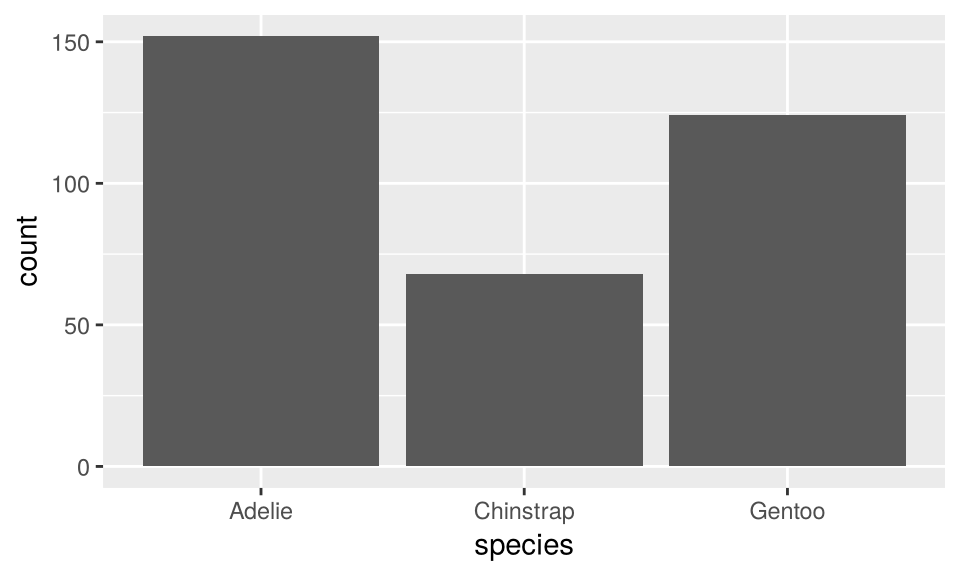

```r
penguins %>%
  ggplot(aes(x = species)) +
  geom_bar()
```

`fct_infreq()` orders levels by how often they appear, and `fct_rev()` flips any order:

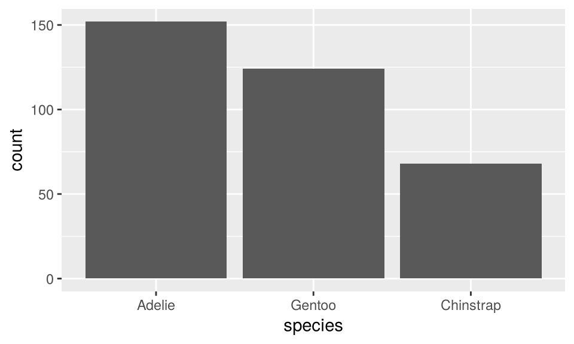

```r
penguins %>%
  mutate(species = fct_infreq(species)) %>%
  ggplot(aes(x = species)) +
  geom_bar()
```

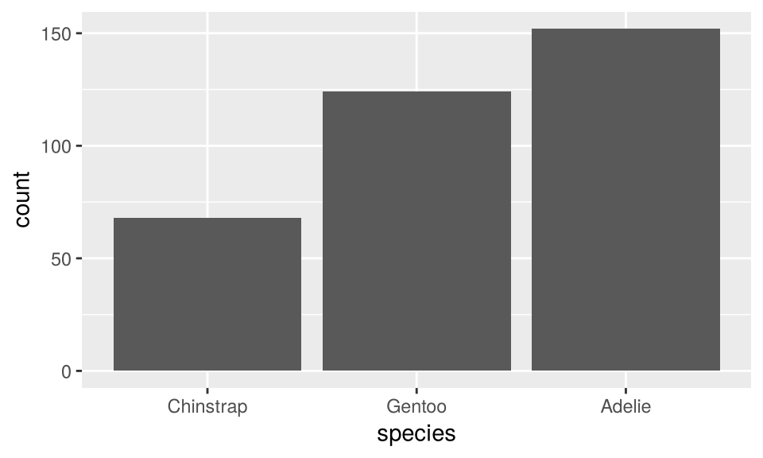

```r
penguins %>%
  mutate(species = fct_rev(fct_infreq(species))) %>%
  ggplot(aes(x = species)) +
  geom_bar()
```

`fct_reorder()` orders levels by a summary of *another* variable. Read the code below as “reorder species by the median of bill length”. We drop the missing bill lengths first so `median()` doesn’t run into any `NA`s.

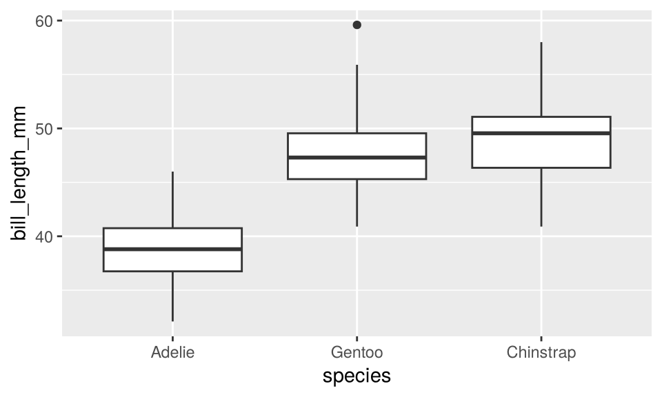

```r
penguins %>%
  filter(!is.na(bill_length_mm)) %>%
  mutate(species = fct_reorder(species, bill_length_mm, .fun = median)) %>%
  ggplot(aes(x = species, y = bill_length_mm)) +
  geom_boxplot()
```

Chinstrap moved past Gentoo. Add `.desc = TRUE` to go from largest to smallest.

`fct_relevel()` lets you move specific levels to the front by hand. This is handy for putting a control or reference group first; models like `lm()` treat the *first* level as the baseline.

```r
penguins %>%
  mutate(species = fct_relevel(species, "Gentoo")) %>%
  pull(species) %>%
  levels()
```

```
## [1] "Gentoo"    "Adelie"    "Chinstrap"
```

### Your turn 1

Make boxplots of `body_mass_g` for each island, with the islands ordered from lightest to heaviest median body mass. Bonus: put the heaviest island on the left.

**Show solution**

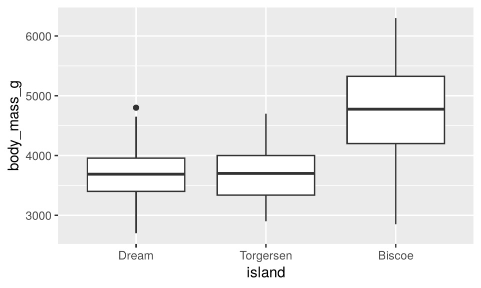

```r
penguins %>%
  filter(!is.na(body_mass_g)) %>%
  mutate(island = fct_reorder(island, body_mass_g, .fun = median)) %>%
  ggplot(aes(x = island, y = body_mass_g)) +
  geom_boxplot()
```

Bonus:

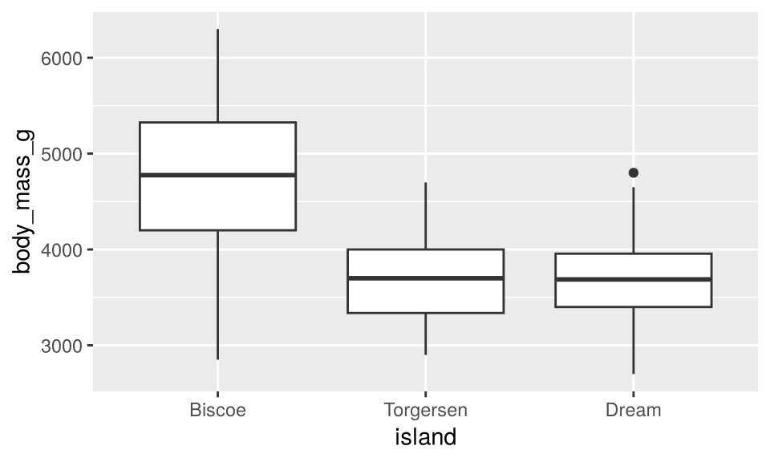

```r
penguins %>%
  filter(!is.na(body_mass_g)) %>%
  mutate(island = fct_reorder(island, body_mass_g, .fun = median, .desc = TRUE)) %>%
  ggplot(aes(x = island, y = body_mass_g)) +
  geom_boxplot()
```

## Changing the levels themselves

`fct_recode()` renames levels. The syntax is `"new" = "old"`, just like `rename()`:

```r
penguins %>%
  mutate(species = fct_recode(species, "Adélie" = "Adelie")) %>%
  count(species)
```

```
## # A tibble: 3 × 2
##   species       n
##   <fct>     <int>
## 1 Adélie      152
## 2 Chinstrap    68
## 3 Gentoo      124
```

`fct_collapse()` lumps several levels into one. Adelie and Chinstrap penguins are about the same size, and Gentoo penguins are much bigger:

```r
penguins %>%
  group_by(species) %>%
  summarise(mean_mass_g = mean(body_mass_g, na.rm = TRUE))
```

```
## # A tibble: 3 × 2
##   species   mean_mass_g
##   <fct>           <dbl>
## 1 Adelie          3701.
## 2 Chinstrap       3733.
## 3 Gentoo          5076.
```

```r
penguins %>%
  mutate(size_group = fct_collapse(species,
                                   "Adelie/Chinstrap" = c("Adelie", "Chinstrap"))) %>%
  count(size_group)
```

```
## # A tibble: 2 × 2
##   size_group           n
##   <fct>            <int>
## 1 Adelie/Chinstrap   220
## 2 Gentoo             124
```

### Unused levels

When you `filter()` out a group, the rows are gone, but the **level is not**:

```r
no_gentoo <- penguins %>%
  filter(species != "Gentoo")

no_gentoo %>% count(species)
```

```
## # A tibble: 2 × 2
##   species       n
##   <fct>     <int>
## 1 Adelie      152
## 2 Chinstrap    68
```

```r
levels(no_gentoo$species)
```

```
## [1] "Adelie"    "Chinstrap" "Gentoo"
```

That “ghost” level can show up in plots and models:

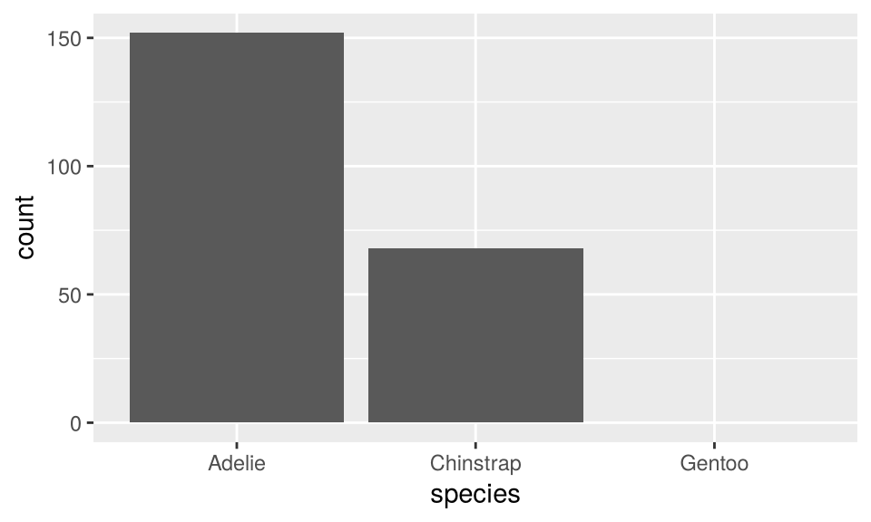

```r
no_gentoo %>%
  ggplot(aes(x = species)) +
  geom_bar() +
  scale_x_discrete(drop = FALSE)
```

`fct_drop()` removes levels that have no data:

```r
no_gentoo <- no_gentoo %>%
  mutate(species = fct_drop(species))
levels(no_gentoo$species)
```

```
## [1] "Adelie"    "Chinstrap"
```

Sometimes you *want* empty levels, to show that you looked and found zero. `fct_expand()` adds them:

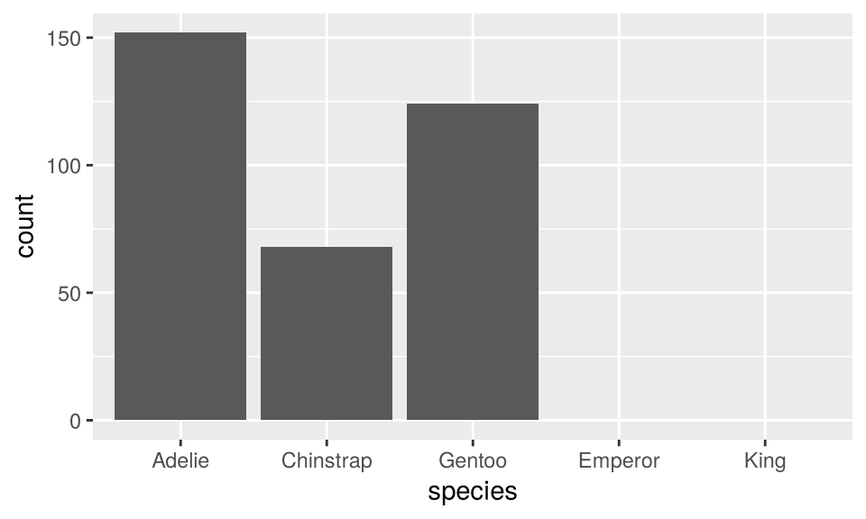

```r
penguins %>%
  mutate(species = fct_expand(species, "Emperor", "King")) %>%
  ggplot(aes(x = species)) +
  geom_bar() +
  scale_x_discrete(drop = FALSE)
```

### Missing values are not a level

```r
penguins %>% count(sex)
```

```
## # A tibble: 3 × 2
##   sex        n
##   <fct>  <int>
## 1 female   165
## 2 male     168
## 3 <NA>      11
```

```r
levels(penguins$sex)
```

```
## [1] "female" "male"
```

`count()` finds 11 penguins with no recorded sex, but `NA` isn’t one of the levels.

### Your turn 2

Using the `sex` column:

1. Recode the levels to “Female” and “Male”.
2. Turn the `NA`s into a real level called “Unknown”. Hint: `fct_na_value_to_level(sex, level = "Unknown")`.
3. Make a bar chart of `sex` with the bars in order of frequency.

**Show solution**

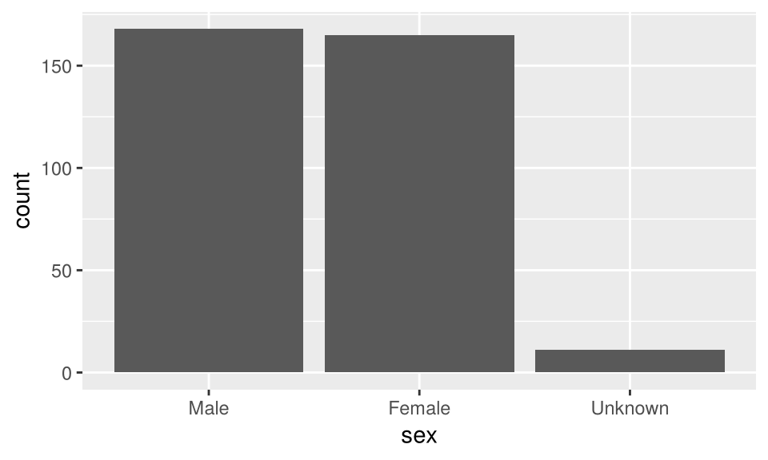

```r
penguins %>%
  mutate(sex = fct_recode(sex, "Female" = "female", "Male" = "male"),
         sex = fct_na_value_to_level(sex, level = "Unknown"),
         sex = fct_infreq(sex)) %>%
  ggplot(aes(x = sex)) +
  geom_bar()
```

Order matters here: each line of `mutate()` works on the result of the line before it.

## Factor gotchas

**Gotcha 1: `as.numeric()` on a factor gives you the codes, not the values.**

```r
yr_fct <- factor(penguins$year)
levels(yr_fct)
```

```
## [1] "2007" "2008" "2009"
```

```r
mean(as.numeric(yr_fct))
```

```
## [1] 2.02907
```

```r
unique(as.numeric(yr_fct))
```

```
## [1] 1 2 3
```

The average year is not 2! Go through character first:

```r
mean(as.numeric(as.character(yr_fct)))
```

```
## [1] 2008.029
```

**Gotcha 2: typos silently become `NA`.**

```r
size_typo <- c("small", "Large", "medium", "large ")
factor(size_typo, levels = c("small", "medium", "large"))
```

```
## [1] small  <NA>   medium <NA>
## Levels: small medium large
```

“Large” (capital L) and “large” (trailing space) aren’t levels, so they quietly become `NA`. No warning! The stricter `fct()` function from forcats stops and tells you instead:

```r
fct(size_typo, levels = c("small", "medium", "large"))
```

```
## Error in `fct()`:
## ! All values of `x` must appear in `levels` or `na`
## ℹ Missing levels: "Large" and "large "
```

An error now is much better than a mystery `NA` later.

# Part 2: Dates and Times with NYC Flights

Dates and times seem simple, but think about it: are there 365 days in every year? 24 hours in every day? The answer to both is no, and that makes date math surprisingly hard. The lubridate package takes care of most of the pain.

## Making dates and date-times from text

```r
today()
```

```
## [1] "2026-11-10"
```

```r
now()
```

```
## [1] "2026-11-10 08:33:49 EST"
```

```r
class(today())
```

```
## [1] "Date"
```

```r
class(now())
```

```
## [1] "POSIXct" "POSIXt"
```

A date written as text is just a string. R can’t do math on it:

```r
d_chr <- "Oct 1 2013"
class(d_chr)
```

```
## [1] "character"
```

```r
d_chr + 1
```

```
## Error in d_chr + 1: non-numeric argument to binary operator
```

lubridate has a family of functions named after the **order** of the year (`y`), month (`m`), and day (`d`). You tell it the order; it figures out the separators and month names.

```r
mdy("Oct 1 2013")
```

```
## [1] "2013-10-01"
```

```r
mdy("October 1st, 2013")
```

```
## [1] "2013-10-01"
```

```r
dmy("1/10/2013")
```

```
## [1] "2013-10-01"
```

```r
ymd("2013-10-01")
```

```
## [1] "2013-10-01"
```

All four are the same Date, and now math works (in days):

```r
d <- mdy("Oct 1 2013")
d + 1
```

```
## [1] "2013-10-02"
```

What date is “01/10/2013”? It depends who wrote it:

```r
mdy("01/10/2013")
```

```
## [1] "2013-01-10"
```

```r
dmy("01/10/2013")
```

```
## [1] "2013-10-01"
```

This is why it’s worth recording dates as `yyyy-mm-dd` (the ISO 8601 standard).

### Date-times and time zones

Add `_hm` or `_hms` to the function name for a date-time. By default, lubridate uses UTC (Coordinated Universal Time):

```r
ymd_hm("2013-10-01 09:00")
```

```
## [1] "2013-10-01 09:00:00 UTC"
```

The flights in our data left New York, so let’s say so. Time zones are named “Continent/City” (Guelph is “America/Toronto”); `OlsonNames()` lists them all.

```r
sched <- ymd_hm("2013-10-01 09:00", tz = "America/New_York")
sched
```

```
## [1] "2013-10-01 09:00:00 EDT"
```

`with_tz()` shows the **same instant** on a different clock:

```r
with_tz(sched, "America/Vancouver")
```

```
## [1] "2013-10-01 06:00:00 PDT"
```

```r
with_tz(sched, "Antarctica/Palmer")    # where the penguins live!
```

```
## [1] "2013-10-01 10:00:00 -03"
```

```r
sched == with_tz(sched, "Antarctica/Palmer")
```

```
## [1] TRUE
```

`force_tz()` keeps the **clock time** but changes the zone, which makes it a *different* instant. Use it only when a time zone was recorded wrong.

```r
force_tz(sched, "Antarctica/Palmer")
```

```
## [1] "2013-10-01 09:00:00 -03"
```

```r
sched == force_tz(sched, "Antarctica/Palmer")
```

```
## [1] FALSE
```

## Building date-times from columns

Let’s make a pared-down version of the flights data:

```r
flights_demo <- flights %>%
  select(year, month, day, hour, minute,
         sched_dep_time, dep_time, dep_delay, carrier, flight)

head(flights_demo)
```

```
## # A tibble: 6 × 10
##    year month   day  hour minute sched_dep_time dep_time dep_delay carrier
##   <int> <int> <int> <dbl>  <dbl>          <int>    <int>     <dbl> <chr>
## 1  2013     1     1     5     15            515      517         2 UA
## 2  2013     1     1     5     29            529      533         4 UA
## 3  2013     1     1     5     40            540      542         2 AA
## 4  2013     1     1     5     45            545      544        -1 B6
## 5  2013     1     1     6      0            600      554        -6 DL
## 6  2013     1     1     5     58            558      554        -4 UA
## # ℹ 1 more variable: flight <int>
```

The scheduled departure date-time is spread over five columns. `make_datetime()` glues numeric pieces together. It also defaults to UTC, so give it a time zone:

```r
flights_demo <- flights_demo %>%
  mutate(sched_dep_dt = make_datetime(year, month, day, hour, minute,
                                      tz = "America/New_York"))

flights_demo %>%
  select(year, month, day, hour, minute, sched_dep_dt) %>%
  head()
```

```
## # A tibble: 6 × 6
##    year month   day  hour minute sched_dep_dt
##   <int> <int> <int> <dbl>  <dbl> <dttm>
## 1  2013     1     1     5     15 2013-01-01 05:15:00
## 2  2013     1     1     5     29 2013-01-01 05:29:00
## 3  2013     1     1     5     40 2013-01-01 05:40:00
## 4  2013     1     1     5     45 2013-01-01 05:45:00
## 5  2013     1     1     6      0 2013-01-01 06:00:00
## 6  2013     1     1     5     58 2013-01-01 05:58:00
```

The *actual* departure time, `dep_time`, is stored as a single number in HHMM format: 517 means 5:17. We can split it with integer division (`%/%`) and the remainder, or “modulo” (`%%`):

```r
517 %/% 100
```

```
## [1] 5
```

```r
517 %% 100
```

```
## [1] 17
```

### Your turn 3

Add a column `dep_dt`: the actual departure date-time of each flight, built from `year`, `month`, `day`, and `dep_time`.

**Show solution**

```r
flights_demo <- flights_demo %>%
  mutate(dep_dt = make_datetime(year, month, day,
                                dep_time %/% 100, dep_time %% 100,
                                tz = "America/New_York"))

flights_demo %>%
  select(sched_dep_dt, dep_time, dep_dt) %>%
  head()
```

```
## # A tibble: 6 × 3
##   sched_dep_dt        dep_time dep_dt
##   <dttm>                 <int> <dttm>
## 1 2013-01-01 05:15:00      517 2013-01-01 05:17:00
## 2 2013-01-01 05:29:00      533 2013-01-01 05:33:00
## 3 2013-01-01 05:40:00      542 2013-01-01 05:42:00
## 4 2013-01-01 05:45:00      544 2013-01-01 05:44:00
## 5 2013-01-01 06:00:00      554 2013-01-01 05:54:00
## 6 2013-01-01 05:58:00      554 2013-01-01 05:54:00
```

Cancelled flights have a missing `dep_time`, so their `dep_dt` is `NA` too.

## Date-time math

Let’s start with one flight, scheduled for 9:00 that left at 9:15. Subtracting two date-times gives a `difftime`:

```r
sched  <- ymd_hm("2013-10-01 09:00", tz = "America/New_York")
actual <- ymd_hm("2013-10-01 09:15", tz = "America/New_York")

actual - sched
```

```
## Time difference of 15 mins
```

A `difftime` picks its own units, which is fine to read but awkward in a column:

```r
ymd_hm("2013-10-02 11:00", tz = "America/New_York") - sched
```

```
## Time difference of 1.083333 days
```

A **duration** always counts seconds. Divide by `dminutes(1)` to get a plain number of minutes:

```r
as.duration(actual - sched)
```

```
## [1] "900s (~15 minutes)"
```

```r
as.duration(actual - sched) / dminutes(1)
```

```
## [1] 15
```

Now let’s do it for every flight, and check our answer against the `dep_delay` column that came with the data:

```r
flights_demo <- flights_demo %>%
  mutate(my_delay = as.duration(dep_dt - sched_dep_dt) / dminutes(1))

flights_demo %>%
  select(sched_dep_dt, dep_dt, dep_delay, my_delay) %>%
  head()
```

```
## # A tibble: 6 × 4
##   sched_dep_dt        dep_dt              dep_delay my_delay
##   <dttm>              <dttm>                  <dbl>    <dbl>
## 1 2013-01-01 05:15:00 2013-01-01 05:17:00         2        2
## 2 2013-01-01 05:29:00 2013-01-01 05:33:00         4        4
## 3 2013-01-01 05:40:00 2013-01-01 05:42:00         2        2
## 4 2013-01-01 05:45:00 2013-01-01 05:44:00        -1       -1
## 5 2013-01-01 06:00:00 2013-01-01 05:54:00        -6       -6
## 6 2013-01-01 05:58:00 2013-01-01 05:54:00        -4       -4
```

```r
flights_demo %>%
  filter(my_delay != dep_delay) %>%
  select(sched_dep_dt, dep_time, dep_dt, dep_delay, my_delay)
```

```
## # A tibble: 1,207 × 5
##    sched_dep_dt        dep_time dep_dt              dep_delay my_delay
##    <dttm>                 <int> <dttm>                  <dbl>    <dbl>
##  1 2013-01-01 18:35:00      848 2013-01-01 08:48:00       853     -587
##  2 2013-01-02 23:59:00       42 2013-01-02 00:42:00        43    -1397
##  3 2013-01-02 22:50:00      126 2013-01-02 01:26:00       156    -1284
##  4 2013-01-03 23:59:00       32 2013-01-03 00:32:00        33    -1407
##  5 2013-01-03 21:45:00       50 2013-01-03 00:50:00       185    -1255
##  6 2013-01-03 23:59:00      235 2013-01-03 02:35:00       156    -1284
##  7 2013-01-04 23:59:00       25 2013-01-04 00:25:00        26    -1414
##  8 2013-01-04 22:45:00      106 2013-01-04 01:06:00       141    -1299
##  9 2013-01-05 23:59:00       14 2013-01-05 00:14:00        15    -1425
## 10 2013-01-05 22:30:00       37 2013-01-05 00:37:00       127    -1313
## # ℹ 1,197 more rows
```

1,207 flights don’t match. These flights left after midnight, but `year`, `month`, and `day` are the *scheduled* date, so our `dep_dt` is a day too early. How far off are we?

```r
flights_demo %>%
  filter(my_delay != dep_delay) %>%
  count(off_by_hours = (dep_delay - my_delay) / 60)
```

```
## # A tibble: 2 × 2
##   off_by_hours     n
##          <dbl> <int>
## 1           23     4
## 2           24  1203
```

Most are off by 24 hours. But four are off by 23. Why?

```r
flights_demo %>%
  filter(dep_delay - my_delay == 23 * 60) %>%
  select(sched_dep_dt, dep_time, dep_delay, my_delay)
```

```
## # A tibble: 4 × 4
##   sched_dep_dt        dep_time dep_delay my_delay
##   <dttm>                 <int>     <dbl>    <dbl>
## 1 2013-03-10 23:59:00        6         7    -1373
## 2 2013-03-10 21:00:00       41       221    -1159
## 3 2013-03-10 23:55:00       44        49    -1331
## 4 2013-03-10 22:53:00      153       180    -1200
```

All four are on March 10, 2013: the night the clocks sprang forward. That “day” was only 23 hours long!

### Durations vs. periods

This is the difference between two kinds of time spans:

- A **duration** is a stopwatch: an exact number of seconds. Functions start with `d`: `ddays()`, `dhours()`, `dminutes()`.
- A **period** is a calendar: human units like “same time tomorrow”. Functions are plain: `days()`, `hours()`, `months()`.

```r
before_dst <- ymd_hm("2013-03-09 13:00", tz = "America/New_York")

before_dst + ddays(1)    # exactly 86,400 seconds later
```

```
## [1] "2013-03-10 14:00:00 EDT"
```

```r
before_dst + days(1)     # same clock time the next day
```

```
## [1] "2013-03-10 13:00:00 EDT"
```

Some clock times never happened at all:

```r
ymd_hm("2013-03-10 02:30", tz = "America/New_York")
```

```
## [1] NA
```

### Fixing the overnight flights

The earliest any flight left was 43 minutes ahead of schedule. So if our `dep_dt` is more than an hour *before* the scheduled time, the flight must really have left the next day. We want “the same clock time, one calendar day later”, which is a period, so we add `days(1)`:

```r
flights_demo <- flights_demo %>%
  mutate(overnight = dep_dt < sched_dep_dt - hours(1),
         dep_dt_fixed = if_else(overnight, dep_dt + days(1), dep_dt),
         my_delay_fixed = as.duration(dep_dt_fixed - sched_dep_dt) / dminutes(1))

flights_demo %>%
  filter(my_delay_fixed != dep_delay) %>%
  nrow()
```

```
## [1] 0
```

No mismatches! Try swapping in `ddays(1)` instead, and the four March 10 flights end up an hour off.

Periods follow the calendar, which can occasionally be awkward:

```r
ymd("2013-01-31") + months(1)       # there is no February 31
```

```
## [1] NA
```

```r
ymd("2013-01-31") %m+% months(1)    # roll back to the last real day
```

```
## [1] "2013-02-28"
```

# Test your understanding

True or false? Decide first, then run the code.

1. The output of this code is a factor with the levels “a” to “f”.

```r
c(factor(c("a", "b", "c")), factor(c("d", "e", "f")))
```

**Show answer**

```
## [1] a b c d e f
## Levels: a b c d e f
```

True, in R 4.1 and later. Older versions of R returned the integer codes (1 2 3 1 2 3) instead! `forcats::fct_c()` combines factors safely in any version.

2. The output of this code is a Date object (not a date-time).

```r
c(ymd("2020-10-13"), ymd_hms("2020-10-13 09:30:00"))
```

**Show answer**

```
## [1] "2020-10-13" "2020-10-13"
```

True. `c()` follows the type of the *first* element, so the 9:30 time is silently dropped. Put the date-time first and you get date-times instead.

# Want more practice?

- The [R4DS Factors chapter](https://r4ds.hadley.nz/factors) and the [forcats reference](https://forcats.tidyverse.org/reference/index.html).
- The [R4DS Dates and Times chapter](https://r4ds.hadley.nz/datetimes), which uses the same flights data.